# Загрузка данных

```python
import pandas as pd
import numpy as np
import matplotlib.pyplot as plt   # библиотека построения графиков
import seaborn as sns             # библиотека визуализации статистики, высокоуровневая, на основе matplotlib
```

```python
df = pd.read_csv("real_estate_data.csv", sep=',', low_memory=False)
```

```python
df.info() # список столбцов с указанием типа даных
```

```
<class 'pandas.core.frame.DataFrame'>
RangeIndex: 403487 entries, 0 to 403486
Data columns (total 17 columns):
id                   403487 non-null int64
type                 403487 non-null object
sub_type             403487 non-null object
start_date           403487 non-null object
end_date             266298 non-null object
listing_type         403487 non-null int64
tom                  403487 non-null int64
building_age         376097 non-null object
total_floor_count    375466 non-null object
floor_no             368191 non-null object
room_count           403487 non-null object
size                 257481 non-null float64
address              403487 non-null object
furnished            0 non-null float64
heating_type         375517 non-null object
price                402772 non-null float64
price_currency       402772 non-null object
dtypes: float64(3), int64(3), object(11)
memory usage: 35.4+ MB
```

```python
# первые строки из набора
df.head()
```

|  | id | type | sub_type | start_date | end_date | listing_type | tom | building_age | total_floor_count | floor_no | room_count | size | address | furnished | heating_type | price | price_currency |
| --- | --- | --- | --- | --- | --- | --- | --- | --- | --- | --- | --- | --- | --- | --- | --- | --- | --- |
| 0 | 1 | Konut | Rezidans | 12/10/18 | 1/9/19 | 2 | 30 | 0 | 20 ve üzeri | 2 | 2+1 | 90.0 | İstanbul/Kartal/Kordonboyu | NaN | Fancoil | 3500.0 | TRY |
| 1 | 2 | Konut | Daire | 2/13/19 | NaN | 1 | 14 | 0 | 20 ve üzeri | 20 ve üzeri | 1+0 | 43.0 | İstanbul/Kartal/Kordonboyu | NaN | Fancoil | 490000.0 | TRY |
| 2 | 3 | Konut | Daire | 10/9/18 | 11/8/18 | 1 | 30 | 0 | 1 | Yüksek Giriş | 2+1 | NaN | Tekirdağ/Çorlu/Reşadiye | NaN | Fancoil | 155000.0 | TRY |
| 3 | 4 | Konut | Rezidans | 9/10/18 | 10/10/18 | 1 | 30 | 3 | 20 ve üzeri | 20 ve üzeri | 6+1 | 450.0 | İstanbul/Beşiktaş/Levent | NaN | Fancoil | 32500000.0 | TRY |
| 4 | 5 | Konut | Rezidans | 12/10/18 | 1/9/19 | 1 | 30 | 0 | 20 ve üzeri | 2 | 2+1 | 90.0 | İstanbul/Kartal/Kordonboyu | NaN | Fancoil | 1450000.0 | TRY |

```python
# размер датасета
df.shape
```

```
(403487, 17)
```

```python
# список колонок
df.columns
```

```
Index(['id', 'type', 'sub_type', 'start_date', 'end_date', 'listing_type',
       'tom', 'building_age', 'total_floor_count', 'floor_no', 'room_count',
       'size', 'address', 'furnished', 'heating_type', 'price',
       'price_currency'],
      dtype='object')
```

```python
df.describe().T
# транспонированная матрица статистичесикх характеристик
```

|  | count | mean | std | min | 25% | 50% | 75% | max |
| --- | --- | --- | --- | --- | --- | --- | --- | --- |
| id | 403487.0 | 201744.000000 | 1.164768e+05 | 1.0 | 100872.5 | 201744.0 | 302615.5 | 4.034870e+05 |
| listing_type | 403487.0 | 1.294235 | 4.677333e-01 | 1.0 | 1.0 | 1.0 | 2.0 | 3.000000e+00 |
| tom | 403487.0 | 57.022739 | 4.435893e+01 | 0.0 | 29.0 | 40.0 | 90.0 | 1.800000e+02 |
| size | 257481.0 | 279.349094 | 9.429195e+03 | 1.0 | 85.0 | 110.0 | 140.0 | 9.482350e+05 |
| furnished | 0.0 | NaN | NaN | NaN | NaN | NaN | NaN | NaN |
| price | 402772.0 | 354641.661933 | 4.809503e+06 | -250.0 | 2500.0 | 199000.0 | 342000.0 | 2.000000e+09 |

## анализ пустых значений

```python
print(df.isna().sum()) # вывод количества неизвестных значений (NaN) в столбцах
print(df.isna().sum() / len(df) * 100) # процент пропущенных значений в колонках
```

```
id                        0
type                      0
sub_type                  0
start_date                0
end_date             137189
listing_type              0
tom                       0
building_age          27390
total_floor_count     28021
floor_no              35296
room_count                0
size                 146006
address                   0
furnished            403487
heating_type          27970
price                   715
price_currency          715
dtype: int64
id                     0.000000
type                   0.000000
sub_type               0.000000
start_date             0.000000
end_date              34.000848
listing_type           0.000000
tom                    0.000000
building_age           6.788323
total_floor_count      6.944709
floor_no               8.747742
room_count             0.000000
size                  36.186048
address                0.000000
furnished            100.000000
heating_type           6.932070
price                  0.177205
price_currency         0.177205
dtype: float64
```

## Выводы

- колонка furnished содержит все значения Nan - удаляем, неинформативная
- колонка end_date = NaN - срок активности на рынке не окончен - нормально
- колонка size - 36% пропусков подумаем, что делать

### Удаляем колонку furnished

```python
df = df.drop(columns = "furnished")
```

### поиск дубликатов строк

```python
print(df.shape, df.drop_duplicates().shape)
```

```
(403487, 16) (403487, 16)
```

дубликатов - нет, все хорошо

## Анализ значений по колонкам

### колонка type¶

```python
# разнообразные значения
df["type"].unique()
```

```
array(['Konut'], dtype=object)
```

Konut = Housing - строения

### колонка sub_type

```python
df["sub_type"].unique()
```

```
array(['Rezidans', 'Daire', 'Villa', 'Müstakil Ev', 'Kooperatif',
       'Yazlık', 'Komple Bina', 'Prefabrik Ev', 'Köşk / Konak / Yalı',
       'Çiftlik Evi', 'Yalı Dairesi', 'Loft'], dtype=object)
```

```python
df["sub_type"].value_counts()
```

```
Daire                  354549
Villa                   21324
Müstakil Ev              9563
Rezidans                 7716
Yazlık                   5929
Komple Bina              2607
Prefabrik Ev              679
Çiftlik Evi               528
Köşk / Konak / Yalı       301
Yalı Dairesi              187
Kooperatif                 70
Loft                       34
Name: sub_type, dtype: int64
```

кодировка понятна только для первого значения "Daire = Flat"

### колонка listing_type

```python
# разнообразные значения
df["listing_type"].unique()
```

```
array([2, 1, 3], dtype=int64)
```

закодирована не как в описании - Satılık = Sale, Kiralık = Rent Будем разбираться

```python
df["listing_type"].value_counts()
```

```
1    287009
2    114236
3      2242
Name: listing_type, dtype: int64
```

### колонка tom - время на рынке

```python
df["tom"].value_counts()
```

```
30     82216
60     22325
0      11151
90      9868
61      6738
1       4855
120     4504
91      4333
62      4292
2       4255
7       4083
6       3894
5       3811
14      3762
4       3741
```

[output cut: 47 more lines]

скорее всего дни

### колонка building_age - возраст здания

“arası” means between

```python
df["building_age"].value_counts()
```

```
0              140174
6-10 arası      50495
11-15 arası     32309
16-20 arası     31333
1               20355
4               19032
21-25 arası     18438
2               17466
3               15651
5               13589
26-30 arası     10581
31-35 arası      4268
36-40 arası      1347
40 ve üzeri      1059
Name: building_age, dtype: int64
```

категориальная переменная - порядковая, надо перевести в отдельную нумерацию, если использовать далее

```python
# словарь перевода - заменяем интервал на середину (6-10 -> 8, ...)
# первый интервал - 1-5 заменим на середину - 3
d = {'0': 0, '1': 3, '2': 3, '3': 3, '4': 3, '5': 3, '6-10 arası': 8, '11-15 arası': 13, '16-20 arası': 18, '21-25 arası': 23, '26-30 arası':28, '31-35 arası': 33,
     '36-40 arası': 38, '40 ve üzeri': 50}
df['building_age'] = df['building_age'].map(d)
df['building_age'].value_counts()
```

```
0.0     140174
3.0      86093
8.0      50495
13.0     32309
18.0     31333
23.0     18438
28.0     10581
33.0      4268
38.0      1347
50.0      1059
Name: building_age, dtype: int64
```

### колонка total_floor_count число этажей в здании

```python
df["total_floor_count"].value_counts()
```

```
4              83082
3              77956
5              70104
10-20 arası    36512
2              27742
6              23348
10             12558
7              12284
8              11207
9               9029
20 ve üzeri     6679
1               4965
Name: total_floor_count, dtype: int64
```

категориальная переменная - порядковая, надо перевести в отдельную нумерацию, если использовать далее

```python
df["total_floor_count"].unique()
```

```
array(['20 ve üzeri', '1', '10-20 arası', '4', '2', '3', '8', '7', '6',
       '5', '10', nan, '9'], dtype=object)
```

```python
# словарь перевода - заменяем интервал на середину (6-10 -> 8, ...)
d = {'1': 1, '2': 2, '3': 3, '4': 4, '5': 5, '6': 6, '7': 7, '8': 8, '9': 9, '10':10, '10-20 arası': 15,
     '20 ve üzeri': 25}
df['total_floor_count'] = df['total_floor_count'].map(d)
df['total_floor_count'].value_counts()
```

```
4.0     83082
3.0     77956
5.0     70104
15.0    36512
2.0     27742
6.0     23348
10.0    12558
7.0     12284
8.0     11207
9.0      9029
25.0     6679
1.0      4965
Name: total_floor_count, dtype: int64
```

### колонка floor_no номер этажа для квартир

```python
df["floor_no"].value_counts()
```

```
2               65864
3               52690
1               46756
4               34465
Yüksek Giriş    24045
5               21193
Müstakil        21165
Bahçe katı      19065
Giriş Katı      10431
6                9747
7                7698
8                6099
Kot 1            5036
Kot 2            4987
9                4855
10               3863
Kot 3            3793
Çatı Katı        3566
Zemin Kat        3441
Komple           2958
11               2894
12               2309
Kot 4            2269
13               1702
20 ve üzeri      1563
14               1328
15                911
En Üst Kat        894
Bodrum Kat        815
16                600
17                373
18                334
Teras Kat         293
19                177
Asma Kat           12
Name: floor_no, dtype: int64
```

```python
# словарь перекодировки по данным описания
d = {'Yüksek Giriş':'1st floor', 'Giriş Katı': 'ground floor',
     'Kot 1':'ground floor', 'Kot 2':'ground floor', 'Kot 3':'ground floor', 'Kot 4':'ground floor',
     'Zemin Kat': 'ground floor', 'En Üst Kat':'ground floor', 'Bodrum Kat':'ground floor', 'Teras Kat':'ground floor',
     'Asma Kat':'ground floor',
     'Çatı Katı': 'penthouse apartment', 'Bahçe katı': 'garden floor flat',
     '20 ve üzeri': 20,
     '1': 1, '2': 2, '3': 3, '4': 4, '5': 5, '6': 6, '7': 7, '8': 8, '9': 9, '10':10,
     '11': 11, '12': 12, '13': 13, '14': 14, '15': 15, '16': 16, '17': 17, '18': 18, '19': 19}
df['floor_no'] =df['floor_no'].map(d)
df['floor_no'].value_counts()
```

```
2                      65864
3                      52690
1                      46756
4                      34465
ground floor           31971
1st floor              24045
5                      21193
garden floor flat      19065
6                       9747
7                       7698
8                       6099
9                       4855
10                      3863
penthouse apartment     3566
11                      2894
12                      2309
13                      1702
20                      1563
14                      1328
15                       911
16                       600
17                       373
18                       334
19                       177
Name: floor_no, dtype: int64
```

### колонка heating_type

```python
df["heating_type"].value_counts()
```

```
Kombi (Doğalgaz)                   204150
Klima                               68197
Merkezi Sistem (Isı Payı Ölçer)     30595
Merkezi Sistem                      22855
Kalorifer (Doğalgaz)                10928
Soba (Kömür)                         8450
Yerden Isıtma                        6958
Yok                                  6098
Kat Kaloriferi                       5655
Kombi (Elektrikli)                   3449
Soba (Doğalgaz)                      2602
Güneş Enerjisi                       1754
Kalorifer (Kömür)                    1503
Jeotermal                            1418
Fancoil                               495
Kalorifer (Akaryakıt)                 410
Name: heating_type, dtype: int64
```

категориальная переменная - надо перекодировать в соответствии с описанием

- Kalorifer (Doğalgaz) = central heating/natural gas,
- Kalorifer (Kömür) = central heating/coal,
- Kombi (Elektrikli) = combi boiler
- Klima = air-conditioning
- Kombi (Doğalgaz) = gas-combi boiler
- Merkezi Sistem = central heating
- Merkezi Sistem (Isı Payı Ölçer) =central heating
- Yerden Isıtma = floor heating
- Soba (Kömür) = heating stove/coal,
- Soba (Doğalgaz) = heating stove/natural gas
- Güneş Enerjisi = solar energy,
- Jeotermal = geothermal energy
- Fancoil = a type of air conditioner
- Kat Kaloriferi = central heating
- Kalorifer (Akaryakıt) = central heating/fuel oil
- Yok = None

```python
# словарь перекодировки по данным описания
d = {'Kombi (Doğalgaz)': 'gas-combi boiler', 'Klima': 'air-conditioning',
     'Merkezi Sistem (Isı Payı Ölçer)': 'central heating', 'Merkezi Sistem': 'central heating',
     'Kalorifer (Doğalgaz)': 'central heating/natural gas', 'Soba (Kömür)': 'heating stove/coal',
     'Yerden Isıtma': 'floor heating', 'Yok': 'None', 'Kat Kaloriferi': 'central heating', 'Kombi (Elektrikli)': 'combi boiler',
     'Soba (Doğalgaz)': 'heating stove/natural gas', 'Güneş Enerjisi': 'solar energy',
     'Kalorifer (Kömür)': 'central heating/coal', 'Jeotermal': 'geothermal energy', 'Fancoil': 'air conditioner',
     'Kalorifer (Akaryakıt)': 'central heating/fuel oil'}
df['heating_type'] =df['heating_type'].map(d)
df['heating_type'].value_counts()
```

```
gas-combi boiler               204150
air-conditioning                68197
central heating                 59105
central heating/natural gas     10928
heating stove/coal               8450
floor heating                    6958
None                             6098
combi boiler                     3449
heating stove/natural gas        2602
solar energy                     1754
central heating/coal             1503
geothermal energy                1418
air conditioner                   495
central heating/fuel oil          410
Name: heating_type, dtype: int64
```

# Сессия 2

## Отбор признаков

```python
# Сначала узнаем число срок, где возраст здания = Nan
df["building_age"].isna().sum()
```

```
27390
```

```python
# подклбчение доп. графических библиотек
from IPython.core.pylabtools import figsize
sns.set(font_scale = 2)
from sklearn.model_selection import train_test_split
```

```python
df["building_age"].value_counts()
```

```
0.0     140174
3.0      86093
8.0      50495
13.0     32309
18.0     31333
23.0     18438
28.0     10581
33.0      4268
38.0      1347
50.0      1059
Name: building_age, dtype: int64
```

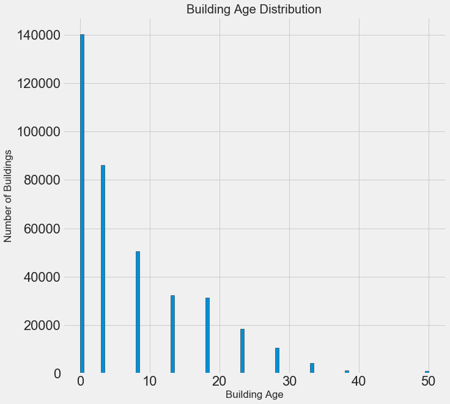

```python
figsize(10, 10)


# Распределение building_age
plt.style.use('fivethirtyeight')
plt.hist(df['building_age'].dropna(), bins =100, edgecolor = 'k');
plt.xlabel('Building Age'); plt.ylabel('Number of Buildings');
plt.title('Building Age Distribution');
```

видим что много новостроек - возраст = 0, остальных количество плавно убывает

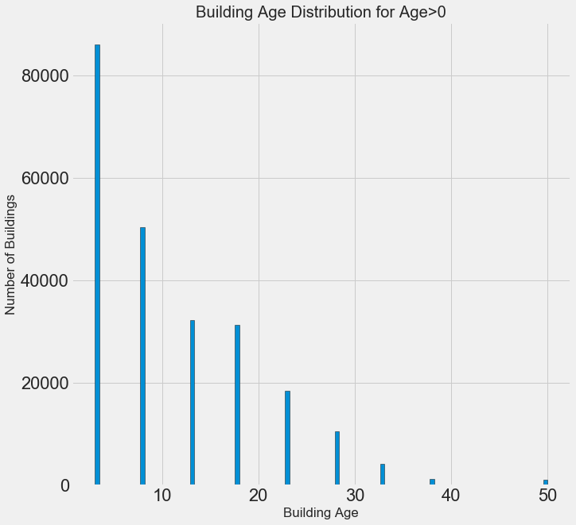

```python
figsize(10, 10)


# Распределение building_age, если не брать новостройки
plt.style.use('fivethirtyeight')
plt.hist(df[df['building_age'] > 0]['building_age'].dropna(), bins =100, edgecolor = 'k');
plt.xlabel('Building Age'); plt.ylabel('Number of Buildings');
plt.title('Building Age Distribution for Age>0');
```

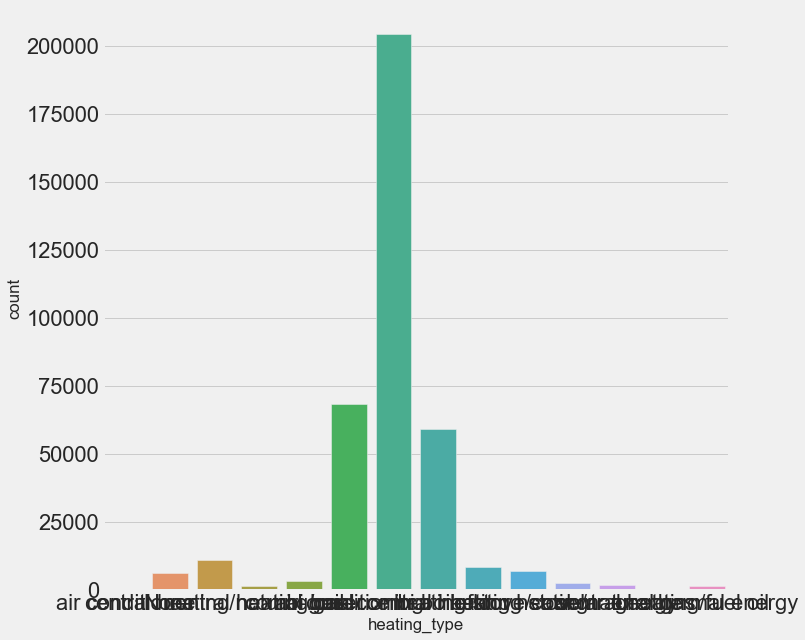

```python
### построим графики гистограмм
sns.countplot(df["heating_type"])
```

```python
df["heating_type"].value_counts()
```

```
gas-combi boiler               204150
air-conditioning                68197
central heating                 59105
central heating/natural gas     10928
heating stove/coal               8450
floor heating                    6958
None                             6098
combi boiler                     3449
heating stove/natural gas        2602
solar energy                     1754
central heating/coal             1503
geothermal energy                1418
air conditioner                   495
central heating/fuel oil          410
Name: heating_type, dtype: int64
```

### посмотрим зависимости building_age от числовых признаков

```python
df.describe().T
```

|  | count | mean | std | min | 25% | 50% | 75% | max |
| --- | --- | --- | --- | --- | --- | --- | --- | --- |
| id | 403487.0 | 201744.000000 | 1.164768e+05 | 1.0 | 100872.5 | 201744.0 | 302615.5 | 4.034870e+05 |
| listing_type | 403487.0 | 1.294235 | 4.677333e-01 | 1.0 | 1.0 | 1.0 | 2.0 | 3.000000e+00 |
| tom | 403487.0 | 57.022739 | 4.435893e+01 | 0.0 | 29.0 | 40.0 | 90.0 | 1.800000e+02 |
| building_age | 376097.0 | 6.943879 | 8.746804e+00 | 0.0 | 0.0 | 3.0 | 13.0 | 5.000000e+01 |
| total_floor_count | 375466.0 | 5.897719 | 4.432264e+00 | 1.0 | 3.0 | 4.0 | 6.0 | 2.500000e+01 |
| size | 257481.0 | 279.349094 | 9.429195e+03 | 1.0 | 85.0 | 110.0 | 140.0 | 9.482350e+05 |
| price | 402772.0 | 354641.661933 | 4.809503e+06 | -250.0 | 2500.0 | 199000.0 | 342000.0 | 2.000000e+09 |

```python
df.corr()
```

|  | id | listing_type | tom | building_age | total_floor_count | size | price |
| --- | --- | --- | --- | --- | --- | --- | --- |
| id | 1.000000 | 0.033796 | -0.003890 | -0.003405 | 0.168879 | 0.008551 | -0.001938 |
| listing_type | 0.033796 | 1.000000 | -0.126534 | 0.175749 | 0.082590 | -0.010385 | -0.044270 |
| tom | -0.003890 | -0.126534 | 1.000000 | -0.020789 | -0.015280 | -0.011847 | 0.011818 |
| building_age | -0.003405 | 0.175749 | -0.020789 | 1.000000 | -0.114209 | 0.011994 | 0.016409 |
| total_floor_count | 0.168879 | 0.082590 | -0.015280 | -0.114209 | 1.000000 | 0.000153 | 0.000802 |
| size | 0.008551 | -0.010385 | -0.011847 | 0.011994 | 0.000153 | 1.000000 | 0.005889 |
| price | -0.001938 | -0.044270 | 0.011818 | 0.016409 | 0.000802 | 0.005889 | 1.000000 |

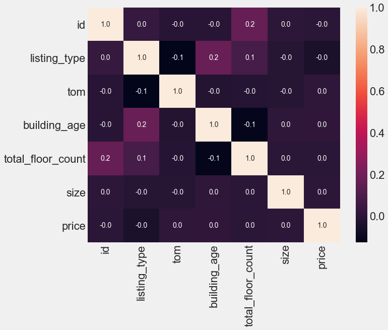

```python
plt.figure(figsize = (10,8))
sns.heatmap(df.corr(), annot = True, fmt = ".01f")
```

Для признака building_age - числовые признаки мало связаны Наибольший по модулю коэффициент корреляции - 0.2 для признака listing_type (какая операция сней производится, но кодировка не известная - она не совпадает с заявленной в описании)

## Отбор признаков

На возраст здания должны влиять признаки:

```
- start_date - дата нвыставления на рынок (чем больше, тем старше дом)
- tom - время на рынке - чем больше, тем выше шансы, что дом старше
- heating_type - тип отопления
- address - наверное, есть районы старой застройки
```

Только эти признаки и имеет смысл рассматривать для обучения

```python
# уберем строки где building_age = NaN
df = df[df["building_age"].isnull() == False]
df.info()
```

```
<class 'pandas.core.frame.DataFrame'>
Int64Index: 376097 entries, 0 to 403325
Data columns (total 16 columns):
id                   376097 non-null int64
type                 376097 non-null object
sub_type             376097 non-null object
start_date           376097 non-null object
end_date             250047 non-null object
listing_type         376097 non-null int64
tom                  376097 non-null int64
building_age         376097 non-null float64
total_floor_count    369204 non-null float64
floor_no             338034 non-null object
room_count           376097 non-null object
size                 244351 non-null float64
address              376097 non-null object
heating_type         369509 non-null object
price                375780 non-null float64
price_currency       375780 non-null object
dtypes: float64(4), int64(3), object(9)
memory usage: 35.9+ MB
```

```python
df.isna().sum()
```

```
id                        0
type                      0
sub_type                  0
start_date                0
end_date             126050
listing_type              0
tom                       0
building_age              0
total_floor_count      6893
floor_no              38063
room_count                0
size                 131746
address                   0
heating_type           6588
price                   317
price_currency          317
dtype: int64
```

```python
# проверим значения признака heating_type
df["heating_type"].value_counts()
```

```
gas-combi boiler               201355
air-conditioning                67161
central heating                 58255
central heating/natural gas     10460
heating stove/coal               8105
floor heating                    6904
None                             5919
combi boiler                     3437
heating stove/natural gas        2487
solar energy                     1724
central heating/coal             1437
geothermal energy                1384
air conditioner                   490
central heating/fuel oil          391
Name: heating_type, dtype: int64
```

```python
# Удалим строки где отопление не известно
df = df[df["heating_type"].isnull() == False]
df.info()
```

```
<class 'pandas.core.frame.DataFrame'>
Int64Index: 369509 entries, 0 to 375516
Data columns (total 16 columns):
id                   369509 non-null int64
type                 369509 non-null object
sub_type             369509 non-null object
start_date           369509 non-null object
end_date             245892 non-null object
listing_type         369509 non-null int64
tom                  369509 non-null int64
building_age         369509 non-null float64
total_floor_count    363376 non-null float64
floor_no             333367 non-null object
room_count           369509 non-null object
size                 240095 non-null float64
address              369509 non-null object
heating_type         369509 non-null object
price                369201 non-null float64
price_currency       369201 non-null object
dtypes: float64(4), int64(3), object(9)
memory usage: 35.2+ MB
```

```python
df_for_analis = df[["start_date", "tom", "address", "heating_type", "building_age"]]
df_for_analis
```

|  | start_date | tom | address | heating_type | building_age |
| --- | --- | --- | --- | --- | --- |
| 0 | 12/10/18 | 30 | İstanbul/Kartal/Kordonboyu | air conditioner | 0.0 |
| 1 | 2/13/19 | 14 | İstanbul/Kartal/Kordonboyu | air conditioner | 0.0 |
| 2 | 10/9/18 | 30 | Tekirdağ/Çorlu/Reşadiye | air conditioner | 0.0 |
| 3 | 9/10/18 | 30 | İstanbul/Beşiktaş/Levent | air conditioner | 3.0 |
| 4 | 12/10/18 | 30 | İstanbul/Kartal/Kordonboyu | air conditioner | 0.0 |
| 5 | 11/9/18 | 30 | İstanbul/Maltepe/Altayçeşme | air conditioner | 3.0 |
| 6 | 1/4/19 | 54 | İstanbul/Kartal/Kordonboyu | air conditioner | 0.0 |
| 7 | 10/3/18 | 92 | İzmir/Urla/M. Fevzi Çakmak | air conditioner | 0.0 |
| 9 | 12/26/18 | 0 | İstanbul/Fatih/Sarıdemir | air conditioner | 3.0 |
| 10 | 11/13/18 | 13 | Muğla/Bodrum/Ortakentyahşi | air conditioner | 0.0 |
| 11 | 1/5/19 | 13 | İzmir/Bayraklı/Adalet | air conditioner | 3.0 |
| 12 | 9/13/18 | 30 | Aydın/Efeler/Ata | air conditioner | 0.0 |
| 13 | 10/3/18 | 30 | Mersin/Yenişehir/Akkent | air conditioner | 0.0 |
| 14 | 9/22/18 | 158 | Manisa/Turgutlu/Şehitler | air conditioner | 3.0 |
| 15 | 10/2/18 | 94 | İzmir/Urla/Çamlıçay | air conditioner | 8.0 |
| 16 | 11/9/18 | 30 | İstanbul/Şişli/İnönü | air conditioner | 0.0 |
| 17 | 12/10/18 | 30 | İstanbul/Kartal/Kordonboyu | air conditioner | 0.0 |
| 18 | 11/22/18 | 97 | İstanbul/Maltepe/Altayçeşme | air conditioner | 3.0 |
| 19 | 9/10/18 | 154 | İstanbul/Beşiktaş/Levent | air conditioner | 3.0 |
| 20 | 9/20/18 | 0 | Ankara/Çankaya/Karataş | air conditioner | 3.0 |
| 21 | 10/9/18 | 141 | İstanbul/Bağcılar/Göztepe | air conditioner | 3.0 |
| 22 | 11/9/18 | 30 | İstanbul/Maltepe/Altayçeşme | air conditioner | 3.0 |
| 23 | 11/23/18 | 52 | Mersin/Yenişehir/Afetevler | air conditioner | 3.0 |
| 24 | 9/13/18 | 61 | Aydın/Efeler/Ata | air conditioner | 0.0 |
| 25 | 10/13/18 | 30 | İstanbul/Kartal/Kordonboyu | air conditioner | 0.0 |
| 26 | 11/1/18 | 118 | Balıkesir/Edremit/Akçay | air conditioner | 3.0 |
| 27 | 11/9/18 | 30 | İstanbul/Maltepe/Altayçeşme | air conditioner | 3.0 |
| 28 | 12/5/18 | 30 | İstanbul/Kartal/Çavuşoğlu | air conditioner | 0.0 |
| 29 | 10/3/18 | 60 | İzmir/Urla/M. Fevzi Çakmak | air conditioner | 0.0 |
| 30 | 10/14/18 | 136 | Muğla/Bodrum/Bitez | air conditioner | 0.0 |
| ... | ... | ... | ... | ... | ... |
| 375487 | 12/27/18 | 30 | Balıkesir/Edremit/Akçay | central heating | 3.0 |
| 375488 | 11/24/18 | 30 | Balıkesir/Edremit/Akçay | central heating | 8.0 |
| 375489 | 10/20/18 | 90 | Muğla/Bodrum/Yalıkavak | central heating | 0.0 |
| 375490 | 10/11/18 | 33 | Çanakkale/Ezine/Dalyan Köyü | central heating | 13.0 |
| 375491 | 10/2/18 | 30 | İzmir/Urla/Sıra | central heating | 8.0 |
| 375492 | 11/22/18 | 30 | Balıkesir/Edremit/Akçay | central heating | 0.0 |
| 375493 | 1/27/19 | 31 | Balıkesir/Edremit/Altınoluk | central heating | 0.0 |
| 375494 | 1/17/19 | 30 | Balıkesir/Edremit/Akçay | central heating | 0.0 |
| 375495 | 10/10/18 | 65 | Balıkesir/Edremit/Akçay | central heating | 0.0 |
| 375496 | 9/26/18 | 46 | Aydın/Kuşadası/Soğucak | central heating | 0.0 |
| 375497 | 9/26/18 | 139 | İzmir/Karabağlar/Muammer Akar | central heating | 33.0 |
| 375498 | 9/13/18 | 150 | Balıkesir/Edremit/Akçay | central heating | 0.0 |
| 375499 | 12/11/18 | 73 | Antalya/Muratpaşa/Yeşilbahçe | central heating | 13.0 |
| 375500 | 2/18/19 | 9 | İzmir/Urla/Denizli | central heating | 18.0 |
| 375501 | 10/27/18 | 123 | Balıkesir/Edremit/Altınoluk | central heating | 3.0 |
| 375502 | 9/17/18 | 8 | Balıkesir/Edremit/Akçay | central heating | 0.0 |
| 375503 | 1/11/19 | 30 | Balıkesir/Edremit/Akçay | central heating | 0.0 |
| 375504 | 10/2/18 | 30 | Balıkesir/Edremit/Akçay | central heating | 0.0 |
| 375505 | 1/18/19 | 40 | Tekirdağ/Şarköy/Cumhuriyet | central heating | 0.0 |
| 375506 | 9/26/18 | 91 | Balıkesir/Edremit/Akçay | central heating | 0.0 |
| 375507 | 1/10/19 | 30 | Balıkesir/Edremit/Altınoluk | central heating | 0.0 |
| 375508 | 10/4/18 | 146 | Aydın/Efeler/Kardeşköy | central heating | 8.0 |
| 375509 | 10/19/18 | 60 | Aydın/Didim/Çamlık | central heating | 0.0 |
| 375510 | 9/15/18 | 25 | Aydın/Didim/Altınkum | central heating | 0.0 |
| 375511 | 10/25/18 | 68 | Çanakkale/Ayvacık/Hamdibey | central heating | 0.0 |
| 375512 | 11/7/18 | 94 | Muğla/Dalaman/Atakent | central heating | 0.0 |
| 375513 | 11/21/18 | 60 | Afyonkarahisar/Merkez/Erenler | central heating | 3.0 |
| 375514 | 9/1/18 | 30 | Aydın/Kuşadası/Kadınlar Denizi | central heating | 0.0 |
| 375515 | 11/9/18 | 62 | Balıkesir/Edremit/Altınoluk | central heating | 3.0 |
| 375516 | 11/10/18 | 90 | Çanakkale/Ayvacık/Küçükkuyu Bld. (Mıhlı) | central heating | 3.0 |

369509 rows × 5 columns

```python
# Остальные признаки - категориальные, используем кодировщик
from sklearn.preprocessing import LabelEncoder # вытаскиваем кодировщика данных
```

```python
le_ht = LabelEncoder() # объект класса кодировщика
```

```python
df_for_analis["heating_type"].isna().sum()
```

```
0
```

```python
df_for_analis["heating_type"] = le_ht.fit_transform(df_for_analis["heating_type"])
```

```python
le_sd = LabelEncoder()
df_for_analis["start_date"] = le_sd.fit_transform(df_for_analis["start_date"])
```

```python
le_ad = LabelEncoder()
df_for_analis["address"] = le_ad.fit_transform(df_for_analis["address"])
```

```python
df_for_analis
```

|  | start_date | tom | address | heating_type | building_age |
| --- | --- | --- | --- | --- | --- |
| 0 | 93 | 30 | 6221 | 1 | 0.0 |
| 1 | 127 | 14 | 6221 | 1 | 0.0 |
| 2 | 61 | 30 | 5210 | 1 | 0.0 |
| 3 | 152 | 30 | 6008 | 1 | 3.0 |
| 4 | 93 | 30 | 6221 | 1 | 0.0 |
| 5 | 91 | 30 | 6275 | 1 | 3.0 |
| 6 | 25 | 54 | 6221 | 1 | 0.0 |
| 7 | 53 | 92 | 7142 | 1 | 0.0 |
| 9 | 110 | 0 | 6155 | 1 | 3.0 |
| 10 | 66 | 13 | 4253 | 1 | 0.0 |
| 11 | 26 | 13 | 6642 | 1 | 3.0 |
| 12 | 155 | 30 | 1165 | 1 | 0.0 |
| 13 | 53 | 30 | 4201 | 1 | 0.0 |
| 14 | 165 | 158 | 3962 | 1 | 3.0 |
| 15 | 42 | 94 | 7154 | 1 | 8.0 |
| 16 | 91 | 30 | 6618 | 1 | 0.0 |
| 17 | 93 | 30 | 6221 | 1 | 0.0 |
| 18 | 76 | 97 | 6275 | 1 | 3.0 |
| 19 | 152 | 154 | 6008 | 1 | 3.0 |
| 20 | 163 | 0 | 739 | 1 | 3.0 |
| 21 | 61 | 141 | 5877 | 1 | 3.0 |
| 22 | 91 | 30 | 6275 | 1 | 3.0 |
| 23 | 77 | 52 | 4200 | 1 | 3.0 |
| 24 | 155 | 61 | 1165 | 1 | 0.0 |
| 25 | 35 | 30 | 6221 | 1 | 0.0 |
| 26 | 62 | 118 | 1385 | 1 | 3.0 |
| 27 | 91 | 30 | 6275 | 1 | 3.0 |
| 28 | 118 | 30 | 6233 | 1 | 0.0 |
| 29 | 53 | 60 | 7142 | 1 | 0.0 |
| 30 | 36 | 136 | 4229 | 1 | 0.0 |
| ... | ... | ... | ... | ... | ... |
| 375487 | 111 | 30 | 1385 | 3 | 3.0 |
| 375488 | 78 | 30 | 1385 | 3 | 8.0 |
| 375489 | 43 | 90 | 4262 | 3 | 0.0 |
| 375490 | 33 | 33 | 5664 | 3 | 13.0 |
| 375491 | 42 | 30 | 7145 | 3 | 8.0 |
| 375492 | 76 | 30 | 1385 | 3 | 0.0 |
| 375493 | 19 | 31 | 1387 | 3 | 0.0 |
| 375494 | 8 | 30 | 1385 | 3 | 0.0 |
| 375495 | 32 | 65 | 1385 | 3 | 0.0 |
| 375496 | 169 | 46 | 1225 | 3 | 0.0 |
| 375497 | 169 | 139 | 6846 | 3 | 33.0 |
| 375498 | 155 | 150 | 1385 | 3 | 0.0 |
| 375499 | 94 | 73 | 1109 | 3 | 13.0 |
| 375500 | 132 | 9 | 7136 | 3 | 18.0 |
| 375501 | 50 | 123 | 1387 | 3 | 3.0 |
| 375502 | 159 | 8 | 1385 | 3 | 0.0 |
| 375503 | 2 | 30 | 1385 | 3 | 0.0 |
| 375504 | 42 | 30 | 1385 | 3 | 0.0 |
| 375505 | 9 | 40 | 5222 | 3 | 0.0 |
| 375506 | 169 | 91 | 1385 | 3 | 0.0 |
| 375507 | 1 | 30 | 1387 | 3 | 0.0 |
| 375508 | 56 | 146 | 1176 | 3 | 8.0 |
| 375509 | 41 | 60 | 1163 | 3 | 0.0 |
| 375510 | 157 | 25 | 1151 | 3 | 0.0 |
| 375511 | 48 | 68 | 5592 | 3 | 0.0 |
| 375512 | 89 | 94 | 4272 | 3 | 0.0 |
| 375513 | 75 | 60 | 224 | 3 | 3.0 |
| 375514 | 151 | 30 | 1222 | 3 | 0.0 |
| 375515 | 91 | 62 | 1387 | 3 | 3.0 |
| 375516 | 63 | 90 | 5603 | 3 | 3.0 |

369509 rows × 5 columns

```python
df_for_analis["building_age"].value_counts()
```

```
0.0     137737
3.0      84601
8.0      49683
13.0     31708
18.0     30746
23.0     18141
28.0     10374
33.0      4181
38.0      1313
50.0      1025
Name: building_age, dtype: int64
```

```python
from sklearn.preprocessing import StandardScaler # класс для масштабирования
```

```python
# выровняем разбросы по переменным
scal = StandardScaler() # создаем объект класса
# матожидание будет 0, дисперсия 1
```

```python
df_scal = scal.fit_transform(df_for_analis.drop("building_age", axis = 1))
```

```python
pd.DataFrame(df_scal, columns=df_for_analis.drop("building_age", axis = 1).columns)
```

|  | start_date | tom | address | heating_type |
| --- | --- | --- | --- | --- |
| 0 | 0.025668 | -0.611589 | 1.030558 | -1.702145 |
| 1 | 0.685493 | -0.974459 | 1.030558 | -1.702145 |
| 2 | -0.595343 | -0.611589 | 0.599725 | -1.702145 |
| 3 | 1.170658 | -0.611589 | 0.939789 | -1.702145 |
| 4 | 0.025668 | -0.611589 | 1.030558 | -1.702145 |
| 5 | -0.013145 | -0.611589 | 1.053570 | -1.702145 |
| 6 | -1.293982 | -0.067284 | 1.030558 | -1.702145 |
| 7 | -0.750596 | 0.794532 | 1.423038 | -1.702145 |
| 8 | 0.355581 | -1.291970 | 1.002432 | -1.702145 |
| 9 | -0.498310 | -0.997138 | 0.191904 | -1.702145 |
| 10 | -1.274575 | -0.997138 | 1.209965 | -1.702145 |
| 11 | 1.228878 | -0.611589 | -1.124032 | -1.702145 |
| 12 | -0.750596 | -0.611589 | 0.169744 | -1.702145 |
| 13 | 1.422944 | 2.291370 | 0.067896 | -1.702145 |
| 14 | -0.964069 | 0.839891 | 1.428151 | -1.702145 |
| 15 | -0.013145 | -0.611589 | 1.199737 | -1.702145 |
| 16 | 0.025668 | -0.611589 | 1.030558 | -1.702145 |
| 17 | -0.304244 | 0.907929 | 1.053570 | -1.702145 |
| 18 | 1.170658 | 2.200653 | 0.939789 | -1.702145 |
| 19 | 1.384131 | -1.291970 | -1.305570 | -1.702145 |
| 20 | -0.595343 | 1.905821 | 0.883964 | -1.702145 |
| 21 | -0.013145 | -0.611589 | 1.053570 | -1.702145 |
| 22 | -0.284838 | -0.112643 | 0.169318 | -1.702145 |
| 23 | 1.228878 | 0.091472 | -1.124032 | -1.702145 |
| 24 | -1.099915 | -0.611589 | 1.030558 | -1.702145 |
| 25 | -0.575937 | 1.384196 | -1.030281 | -1.702145 |
| 26 | -0.013145 | -0.611589 | 1.053570 | -1.702145 |
| 27 | 0.510834 | -0.611589 | 1.035672 | -1.702145 |
| 28 | -0.750596 | 0.068792 | 1.423038 | -1.702145 |
| 29 | -1.080509 | 1.792424 | 0.181676 | -1.702145 |
| ... | ... | ... | ... | ... |
| 369479 | 0.374987 | -0.611589 | -1.030281 | -1.090695 |
| 369480 | -0.265431 | -0.611589 | -1.030281 | -1.090695 |
| 369481 | -0.944662 | 0.749173 | 0.195739 | -1.090695 |
| 369482 | -1.138729 | -0.543551 | 0.793195 | -1.090695 |
| 369483 | -0.964069 | -0.611589 | 1.424316 | -1.090695 |
| 369484 | -0.304244 | -0.611589 | -1.030281 | -1.090695 |
| 369485 | -1.410421 | -0.588909 | -1.029428 | -1.090695 |
| 369486 | -1.623894 | -0.611589 | -1.030281 | -1.090695 |
| 369487 | -1.158135 | 0.182189 | -1.030281 | -1.090695 |
| 369488 | 1.500571 | -0.248719 | -1.098464 | -1.090695 |
| 369489 | 1.500571 | 1.860462 | 1.296899 | -1.090695 |
| 369490 | 1.228878 | 2.109935 | -1.030281 | -1.090695 |
| 369491 | 0.045075 | 0.363624 | -1.147897 | -1.090695 |
| 369492 | 0.782526 | -1.087855 | 1.420481 | -1.090695 |
| 369493 | -0.808816 | 1.497592 | -1.029428 | -1.090695 |
| 369494 | 1.306505 | -1.110535 | -1.030281 | -1.090695 |
| 369495 | -1.740334 | -0.611589 | -1.030281 | -1.090695 |
| 369496 | -0.964069 | -0.611589 | -1.030281 | -1.090695 |
| 369497 | -1.604487 | -0.384795 | 0.604839 | -1.090695 |
| 369498 | 1.500571 | 0.771853 | -1.030281 | -1.090695 |
| 369499 | -1.759740 | -0.611589 | -1.029428 | -1.090695 |
| 369500 | -0.692376 | 2.019218 | -1.119345 | -1.090695 |
| 369501 | -0.983476 | 0.068792 | -1.124885 | -1.090695 |
| 369502 | 1.267691 | -0.724986 | -1.129999 | -1.090695 |
| 369503 | -0.847629 | 0.250227 | 0.762512 | -1.090695 |
| 369504 | -0.051958 | 0.839891 | 0.200001 | -1.090695 |
| 369505 | -0.323651 | 0.068792 | -1.525035 | -1.090695 |
| 369506 | 1.151252 | -0.611589 | -1.099742 | -1.090695 |
| 369507 | -0.013145 | 0.114151 | -1.029428 | -1.090695 |
| 369508 | -0.556530 | 0.749173 | 0.767200 | -1.090695 |

369509 rows × 4 columns

```python
df_scal
```

```
array([[ 0.02566821, -0.61158869,  1.03055777, -1.70214476],
       [ 0.68549307, -0.97445855,  1.03055777, -1.70214476],
       [-0.59534343, -0.61158869,  0.59972495, -1.70214476],
       ...,
       [ 1.15125179, -0.61158869, -1.0997422 , -1.0906952 ],
       [-0.01314502,  0.11415103, -1.02942823, -1.0906952 ],
       [-0.5565302 ,  0.74917329,  0.76720002, -1.0906952 ]])
```

## Разбиение выборки на тестовую и обучающую

```python
x = df_scal.copy() # копирует массив в x
y = df["building_age"] # целевая переменная y
```

```python
from sklearn.model_selection import train_test_split
```

выборка не сбалансированная по классам, поэтому проведеем случайное разбиение, выравненное по целевой переменной

```python
x_train, x_test, y_train, y_test = train_test_split(x, y, test_size = 0.3, random_state = 1, stratify = y)
```

## Обучение

так как есть категориалный признаки, то ограничимся методами:

- Дерево решений
- случайный лес

### Дерево решений

```python
from sklearn.tree import DecisionTreeClassifier # загрузка класса дерева решений
```

```python
clf = DecisionTreeClassifier(random_state=1)
```

```python
clf.fit(x_train, y_train) # обучение модели
```

```
DecisionTreeClassifier(random_state=1)
```

```python
clf.score(x_test, y_test) # accuracy
```

```
0.12580546179809757
```

Очень плохой результат

```python
y_test[:5]
```

```
130295    0.0
276295    0.0
85229     0.0
47652     0.0
287407    0.0
Name: building_age, dtype: float64
```

```python
y_pred = clf.predict(x_test) # предсказали и вывели первые 10
y_pred[:10]
```

```
array([18., 18., 13., 13.,  8.,  8., 18., 13.,  8., 18.])
```

```python
from sklearn.metrics import accuracy_score, classification_report, confusion_matrix
```

```python
accuracy_score(y_test, y_pred)
```

```
0.12580546179809757
```

```python
print(classification_report(y_test, y_pred));
```

[output not shown]

[figure not shown]

```python
# посмотрим на матрицу ошибок
sns.heatmap(confusion_matrix(y_test, y_pred), annot = True, fmt=".0f")
```

```python
#Просто ужас - некоторые классы вообще не распознаются
```

### Настройка гиперпараметров модели

может быть удастся за счет настройки повысить шансы на удачную классификацию

```python
clf = DecisionTreeClassifier(random_state=1)
from sklearn.model_selection import GridSearchCV
# сетка поиска Cross Validation - перебор тестовой выборки ровно с одинаковым шагом (к-блочная перекрестная проверка)
params = {"max_depth": np.arange(1,7,1), "min_samples_leaf": range(1,7,1)} # словарь с гиперпараметрами
# настраниваем глубину дерева - max_depth - 1,2,...,6
# и сколько наблюдений в конечном листе - min_samples_lea - 1,2,...,6
```

```python
grid = GridSearchCV(clf, params, cv = 5, n_jobs = -1)
```

```python
%%timeit
grid.fit(x_train, y_train) # обучение на кросс-валидации
```

```
1min 21s ± 12.4 s per loop (mean ± std. dev. of 7 runs, 1 loop each)
```

```python
grid.best_params_ # параметры лучшей модели
```

```
{'max_depth': 6, 'min_samples_leaf': 6}
```

```python
best_clf = grid.best_estimator_ # лучший алгоритм
# по результатам предыдущего обучения
```

```python
print(classification_report(y_test, y_pred))
```

[output not shown]

```python
grid.best_score_
```

```
0.41774472372818644
```

#### Анализ результатов примеенения модели "Дерево решений"

Результаты улучшились с 0.12 до 0.41, но все равно плохие Случайный лес не успею запустить

```python
### Случайный лес
```

```python
from sklearn.ensemble import RandomForestClassifier
```

```python
rf_cls = RandomForestClassifier(n_estimators=300, random_state = 1)
rf_cls.fit(x_train, y_train)
```

```python
y_pred = rf_cls.predict(x_test)
print(classification_report(y_test, y_pred))
```

```python
params = {"n_estimators": [100,200,300]} # словарь с гиперпараметрами
# в случайном лесу важно число деревьев
# max_depth - не надо варьировать,
# min_saples_leaf - не надо задавать
grid = GridSearchCV(rf_cls, params, cv = 5, n_jobs = -1)
%%timeit
grid.fit(x_train, y_train) # обучение на кросс-валидации
```

```python
grid.best_params_ # параметры лучшей модели
```

```python
best_clf = grid.best_estimator_ # лучший алгоритм
y_pred = best_clf.predict(x_test)
print(classification_report(y_test, y_pred))
```

```python
grid.best_score_
```

```python
#### Анализ результатов примеенения модели "Случайный лес"
```

[output not shown]

с преобразованием даты из строки в тип дата не знаком, поэтому закодирвал как и все отсальные номинальные признаки